# Homework 03

Susanna Bravi, Camilla Brigandì, Lorenzo Pannacci

2024-02-10

```r
library("tseries")
library("ggplot2")
library("gridExtra")
library("corrplot")
library("igraph")
library("network")
library("knitr")
library("viridis")
library("GGally")
```

# Introductory Exercise - Easy game with 3 players

In this starting exercise, we have to complete the definition of the characteristic function $\nu$ of a given game and find the Shapley value $\psi^G$ of each player in the game. In particular, we have three different players $\mathcal{P} = \textit{\{A, B, C\}}$ and their working hours. The goal of the “game” is to optimize their working schedule in order to avoid overlapping hours, since the characteristic function of this game is defined as $ν(\mathsf{C}) = \textit{\{# of hours potentially saved by well organized coalition\}}$ for a given coalition $\mathsf{C} \subseteq \mathcal{P}$.

The hours in which the players are available to work are the following:

| **Player** | **Working hours** |
| --- | --- |
| **A** | 14:00 - 17:00 |
| **B** | 11:00 - 16:00 |
| **C** | 9:00 - 13:00 |

The text explicitly says, but it is clear from the definition, that $\nu(A) = \nu(B) = \nu(C) = 0$ and $\nu(ABC) = 4$.

Our job starts here. First of all, we notice that since $\mathcal{P} = \{A, B, C\}$ all the possible coalitions are

$$2^\mathcal{P} = \{ \{A\}, \, \{B\}, \,
\{C\}, \, \{A, B\}, \, \{A, C\}, \, \{B, C\}, \, \{A, B, C\}
\}$$

so we only have to define $\nu$ for the subsets of $\mathcal{P}$ of two elements, those being $\{A, B\},\{A, C\}, \{B, C\}$. From the definition of the characteristic function $\nu$ given above, we have that:

- $\nu(AB) = 2$, since their *possible* working hours overlap from 14:00 to 16:00.
- $\nu(BC) = 2$, since their *possible* working hours overlap from 11:00 to 13:00.
- $\nu(AC) = 0$, since there are no *possible* working hours overlapping.

So, to summarize the characteristic function, we have:

$$\nu(S) =
\begin{cases}
4 & \text{if } S = \{A, B, C\} \\
2 & \text{if } S \in \{\{A, B\}, \{B, C\}\} \\
0 & \text{if } S \in \{\{A\}, \{B\}, \{C\}, \{A, C\}\}
\end{cases}$$

We can also observe that:

$$\nu(\mathsf{C}_1) \le \nu(\mathsf{C}_2) \; \forall \;
\mathsf{C}_1 \subseteq \mathsf{C}_2$$

the game is therefore *monotone* and could easily be re-scaled to make it become a *simple game* by just dividing the obtained Shapley values by $\nu(\mathcal{P})$. This new game $G'$ is analogous to original one but gives to the Shapley values of each player a more immediate meaning of “power” of the player.

Now we need to compute the Shapley values for the game $G = (\mathcal{P}, \nu)$. Recalling the definition of Shapley we have:

$$\begin{equation*}
\psi^G(j) = \sum_{\mathsf{C}: j \notin \mathsf{C}} \frac{(\# \mathsf{C})
!(p-1-\# \mathsf{C}) !}{p !}(\nu(\mathsf{C} \cup\{j\})-\nu(\mathsf{C}))
\end{equation*}$$

where $\mathsf{C}$ is a coalition of the players $\mathcal{P}$ and $p = \#\mathcal{P}$. Applying the definition over the three players of the game we obtain their Shapley values:

$$\begin{align*}
\psi^G(A) &= \sum_{\mathrm{S}: A \notin \mathrm{S}} \frac{(\#
\mathrm{S}) !(p-1-\# \mathrm{S}) !}{p !}(\nu(\mathrm{S}
\cup\{A\})-\nu(\mathrm{S})) = \\
&=(\nu(ABC) - \nu(BC) ) \frac{2!}{3!} (3-1-2)! + ( (\nu(AB) -
\nu(B)) + (\nu(AC) - \nu(C)) ) \frac{1! 1!}{3!} = \\
&= (4-2) \, \frac{2}{6} + 2 \, \frac{1}{6} \\
&= 1 \\
\psi^G(B) &= \sum_{\mathrm{S}: B \notin \mathrm{S}} \frac{(\#
\mathrm{S}) !(p-1-\# \mathrm{S}) !}{p !}(\nu(\mathrm{S}
\cup\{B\})-\nu(\mathrm{S})) = \\
&=(\nu(ABC) - \nu(AC) ) \frac{2}{6} + ( (\nu(AB) - \nu(A)) +
(\nu(BC) - \nu(C)) ) \frac{1}{6} = \\
&= 4 \, \frac{2}{6} + 4 \, \frac{1}{6} \\
&= 2 \\
\psi^G(C) &= \sum_{\mathrm{S}: C \notin \mathrm{S}} \frac{(\#
\mathrm{S}) !(p-1-\# \mathrm{S}) !}{p !}(\nu(\mathrm{S}
\cup\{C\})-\nu(\mathrm{S})) = \\
&=(\nu(ABC) - \nu(AB) ) \frac{2}{6} + ( (\nu(AC) - \nu(A)) +
(\nu(BC) - \nu(B)) ) \frac{1}{6} = \\
&= 2 \, \frac{2}{6} + 2 \, \frac{1}{6} \\
&= 1 \\
\end{align*}$$

Summarizing:

$$\psi^G(j)=
\begin{cases}
1 & \text{if } j \in \{A, C\} \\
2 & \text{if } j=B \\
\end{cases}$$

And if we re-scale the payoff values to transform the game into a *simple* one:

$$\psi^{G'}(j)=
\begin{cases}
\frac{1}{4} & \text{if } j \in \{A, C\} \\
\frac{1}{2} & \text{if } j=B \\
\end{cases}$$

Those results tell us that the power of the player $B$ is the double of those of players $A$ and $C$. This is because player $B$ intersects both $A$ and $C$ for two hours each while they intersect only with $B$; if we intuitively give equal “merit” to each player that causes an intersection we end up with two hours of merit for $B$ and one hour each for $A$ and $C$, that is the Shapley values of the original game $G$.

# Exercise 2 - Statistical

## Chosen Portfolio

The second exercise require us to create a portfolio of $p$ stocks to be considered in the time span that goes from the start of 2020 to the end of 2023, a time period defined by several great global events, first of all the Covid pandemic. The number of stocks $p$ that was chosen is 44 and they were taken across all the *11 Global Industry Classification Standard* (GICS) sectors.  
It is expected that stocks from the same sector are more correlated with each other, and in the homework we will test whether this assumption is true or not.

We list below all the considered stocks divided by sector:

| **GICS Sector** | **Stocks** |  |  |  |  |  |  |
| --- | --- | --- | --- | --- | --- | --- | --- |
| **Consumer Discretionary** | Ford Motor Company (F) | General Motors (GM) | Tesla (TSLA) | Amazon (AMZN) | Ebay (EBAY) | Expedia Group (EXPE) | Booking Holdings (BKNG) |
| **Consumer Staples** | Philip Morris International (PM) | Altria (MO) | Colgate - Palmolive (CL) | Kraft Heinz (KHC) |  |  |  |
| **Communiction Sevices** | Meta Platforms (META) | Netflix (NFLX) | Warner Bros Discoveries (WBD) | Paramount (PARA) | Walt Disney (DIS) |  |  |
| **Energy** | Hess Corporation (HES) | Coterra (CTRA) | ExxonMobil (XOM) |  |  |  |  |
| **Financials** | Nasdaq, Inc. (NDAQ) | Assurant (AIZ) | Mastercard (MA) | Paypal (PYPL) | VISA (V) |  |  |
| **Health Care** | Pfizer (PFE) | Johnson & Johnson (JNJ) | Moderna (MRNA) |  |  |  |  |
| **Industrials** | Delta Air Lines (DAL) | Uber (UBER) | Boeing (BA) | FedEx (FDX) |  |  |  |
| **IT** | HP (HPQ) | Nvidia (NVDA) | Intel (INTC) | AMD (AMD) |  |  |  |
| **Materials** | Nucor (NUE) | Packaging Corporation Of America (PKG) | Steel Dynamics (STLD) |  |  |  |  |
| **Real Estate** | SBA Communications (SBAC) | Equinix (EQIX) | CoStar Group (CSGP) |  |  |  |  |
| **Utilities** | Edison International (EIX) | Atmos Energy (ATO) | American Water Works (AWK) |  |  |  |  |

```r
# Create extraction function

get_stock_data = function(stock_name){
  stock_data <- get.hist.quote(instrument=stock_name, start="2020-01-01",
                               end="2023-12-31", quote=c("Open","Close"),
                               provider="yahoo", drop=TRUE)
  stock_data$y <- stock_data$Close/stock_data$Open

  return(stock_data)
}


# 1. Communiction Sevices ---------------

# Meta Platforms (META) - Subindustry : Interactive Media & Services
meta <- get_stock_data(stock_name = "META")

# Netflix (NFLX) - Subindustry : Movies & Entertainment
nflx <- get_stock_data(stock_name = "NFLX")

# Paramount (PARA) - Subindustry : Movies & Entertainment
para <- get_stock_data(stock_name = "PARA")

# Walt Disney (DIS) - Subindustry : Movies & Entertainment
dis <- get_stock_data(stock_name = "DIS")

# Warner Bros Discoveries (WBD) - Subindustry: Broadcasting
wb <- get_stock_data(stock_name = "WBD")

# 2. Consumer Discretionary  --------------------------------------------------

# Ford Motor company (F) - Subindustry: Automobile Manufacturers
ford <- get_stock_data(stock_name = "F")

# General Motors (GM) - Subindustry: Automobile Manufacturers
gm <- get_stock_data(stock_name = "GM")

# Tesla (TSLA) - Subindustry: Automobile Manufacturers
tsla <- get_stock_data(stock_name = "TSLA")

# Amazon (AMZN) - Subindustry : Broadline retail
amzn <- get_stock_data(stock_name = "AMZN")

# Ebay (EBAY) - Subindustry : Broadline Retail
ebay <- get_stock_data(stock_name = "EBAY")

# Expedia Group (EXPE) - Subindustry: Hotels, Resorts & Cruise Lines
expe <- get_stock_data(stock_name = "EXPE")

# Booking Holdings (BKNG) - Subindustry: Hotels, Resorts & Cruise Lines
bkng <- get_stock_data(stock_name = "BKNG")

# 3. Consumer Staples -----------------------------------------------------

# Philip Morris International (PM) - Subindustry: Tobacco
pm <- get_stock_data(stock_name = "PM")

# Altria (MO) - Subindustry: Tobacco
mo <- get_stock_data(stock_name = "MO")

# Colgate - Palmolive (CL) - Subindustry : Household products
cl <- get_stock_data(stock_name = "CL")

# Kraft Heinz (KHC) - Subindustry : Packaged Foods & Meats
khc <- get_stock_data(stock_name = "KHC")

# 4. Energy ---------------------------------------------------------------

# Hess Corporation (HES) - Subindustry : Integrated Oil & Gas
hes <- get_stock_data(stock_name = "HES")

# Coterra Energy Inc (CTRA) - Subindustry : Oil & Gas Exploration & Production
ctra <- get_stock_data(stock_name = "CTRA")

# ExxonMobil (XOM) - Subindustry : Integrated Oil & Gas
xom <- get_stock_data(stock_name = "XOM")


# 5. Financials -----------------------------------------------------------

# Nasdaq, Inc. (NDAQ) - Subindustry: Financial Exchange & Data
ndaq <- get_stock_data(stock_name = "NDAQ")

# Assurant (AIZ) - Subindustry : Multi - line insurance
aiz <- get_stock_data(stock_name = "AIZ")

# Mastecard (MA) - Subindustry : Transaction & Payment Processing Services
ma <- get_stock_data(stock_name = "MA")

# Paypal (PYPL) - Subindustry : Transaction & Payment Processing Services
pypl <- get_stock_data(stock_name = "PYPL")

# VISA (V) - Subindustry : Transaction & Payment Processing Services
v <- get_stock_data(stock_name = "V")

# 6. Health Care -----------------------------------------------------------

# Pfizer (PFE) - Subindustry : Pharmaceuticals
pfe <- get_stock_data(stock_name = "PFE")

# Johnson & Johnson (JNJ) - Subindustry : Pharmaceuticals
jnj <- get_stock_data(stock_name = "JNJ")

# Moderna (MRNA) - Subindustry : Biotechnology
mrna <- get_stock_data(stock_name = "MRNA")

# 7. Industrials ----------------------------------------------------------

# Delta Air Lines (DAL) - Subindustry : Passenger Airlines
dal <- get_stock_data(stock_name = "DAL")

# Uber (UBER) - Subindustry : Passenger Ground Transportation
uber <- get_stock_data(stock_name = "UBER")

# Boeing (BA) - Subindustry : Aerospace & Defense
ba <- get_stock_data(stock_name = "BA")

# FedEx (FDX) - Subindustry : Air Freight & Logistics
fdx <- get_stock_data(stock_name = "FDX")

# 8. IT ------------------------------------------------------------------

# HP (HPQ) - Subindustry : Technology Hardware, Storage & Peripherals
hpq <- get_stock_data(stock_name = "HPQ")

# Nvidia (NVDA) - Subindustry : Semiconductors
nvda <- get_stock_data(stock_name = "NVDA")

# Intel (INTC) - Subindustry : Semiconductors
intc <- get_stock_data(stock_name = "INTC")

# AMD (AMD) - Subindustry : Semiconductors
amd <- get_stock_data(stock_name = "AMD")

# 9. Materials -----------------------------------------------------------

# Packaging Corporation Of America (PKG) - Subindustry : Paper & Plastic Packaging Products & Materials
pkg <- get_stock_data(stock_name = "PKG")

# Steel Dynamics (STLD) - Subindustry: Steel
stld <- get_stock_data(stock_name = "STLD")

# Nucor (NUE) - Subindustry: Steel
nue <- get_stock_data(stock_name = "NUE")


# 10. Real Estate ---------------------------------------------------------

# SBA Communications (SBAC) - Subindustry : Telecom Tower REITs
sbac <- get_stock_data(stock_name = "SBAC")

# Equinix (EQIX) - Subindustry : Data Center REITs
eqix <- get_stock_data(stock_name = "EQIX")

# CoStar Group (CSGP) - Subindustry : Real Estate Services
csgp <- get_stock_data(stock_name = "CSGP")


# 11. Utilities ----------------------

# Edison International (EIX) - Subindustry : Electric Utilities
eix <- get_stock_data(stock_name = "EIX")

# Atmos Energy (ATO) - Subindustry : Gas Utilities
ato <- get_stock_data(stock_name = "ATO")

# American Water Works (AWK) - Subindustry: Water Utilities
awk <- get_stock_data(stock_name = "AWK")
```

While for some GICS sectors we have chosen to take stocks from different sub-industries, as for the *Utilities* sector where we have used electric, gas and water utilities, for others we focused on a specific sub-industry, as for example tobacco in the *Consumer Staples* sector. In the same fashion used different *Movies & Entertainment* companies, as well as *Automobile Manufacturers*, *Broadline Retail* or *Pharmaceuticals*, the last two were chosen believing they were particularly relevant in the studied time span.

We also inserted stocks that even being from different industries we suspect to be deeply connected one to another and to have been heavily influenced by the Covid pandemic, those being Booking and Expedia (travel agencies), Delta Airlines (public flight airline) and Boeing (aerospace manufacturer). Here we could expect to find correlations given by the abrupt stop and subsequent slow restart to tourism the world experienced in the examined time period, factor that we may suppose forced a specific similar behavior to the stocks.

To have an idea of how our data looks we can plot for example the closing prices of the *Health Care* sector.

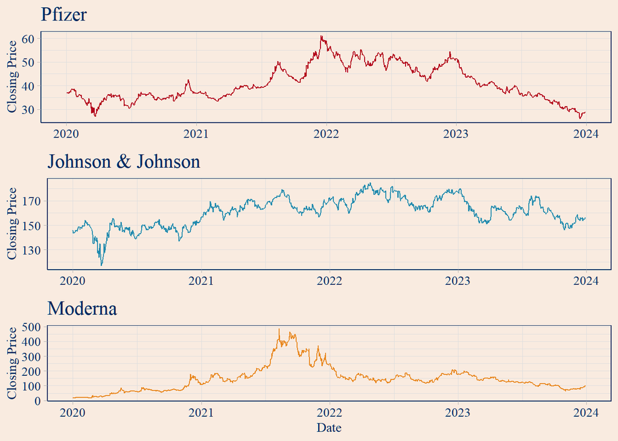

Once the data are obtained, it is necessary to construct the data matrix $\mathbb{X} = [x_{t,j}]_{t,j}$ which contains the logarithm of the relative closing prices on the columns and on the rows the *time*.

```r
# DATA MATRIX -------------------------------------------------------------------------

stocks_names <- c( 'AMZN', 'AIZ', 'ATO', 'AWK', 'CL', 'CTRA', 'CSGP',
                   'EIX', 'EQIX', 'EXPE', 'FORD', 'KHC', 'HES', 'HPQ',
                   'DAL', 'MA', 'META', 'MRNA', 'NFLX', 'NDAQ', 'NVDA',
                   'BA', 'PFE', 'PM', 'PKG', 'SBAC', 'STLD', 'UBER',
                   'WB', 'XOM', "GM", "TSLA", "EBAY", "INTC", "AMD",
                   "PARA", "DIS", "JNJ", "MO", "NUE", "BKNG", "PYPL",
                   "V", "FDX")

categories <- list(c("META", "NFLX", "PARA", "DIS", "WB"),
                  c("FORD", "GM", "TSLA", "AMZN", "EBAY", "EXPE", "BKNG"),
                  c("PM", "MO", "CL", "KHC"),
                  c("HES", "CTRA", "XOM"),
                  c("NDAQ", "AIZ", "MA", "PYPL", "V"),
                  c("PFE", "JNJ", "MRNA"),
                  c("DAL", "UBER", "BA", "FDX"),
                  c("HPQ", "NVDA", "INTC", "AMD"),
                  c("PKG", "STLD", "NUE"),
                  c("SBAC", "EQIX", "CSGP"),
                  c("EIX", "ATO", "AWK"))

stocks_close <- cbind(amzn$Close, aiz$Close, ato$Close, awk$Close,
                      cl$Close, ctra$Close, csgp$Close, eix$Close,
                      eqix$Close, expe$Close, ford$Close, khc$Close,
                      hes$Close, hpq$Close, dal$Close, ma$Close,
                      meta$Close, mrna$Close, nflx$Close, ndaq$Close,
                      nvda$Close, ba$Close, pfe$Close,pm$Close, pkg$Close,
                      sbac$Close, stld$Close, uber$Close, wb$Close,
                      xom$Close, gm$Close, tsla$Close, ebay$Close,
                      intc$Close, amd$Close, para$Close, dis$Close,
                      jnj$Close, mo$Close, nue$Close, bkng$Close,
                      pypl$Close, v$Close, fdx$Close)

difflog <- function(x) diff(log(x))

stocks_values <- apply(stocks_close, MARGIN = 2, FUN = difflog)

colnames(stocks_values) <- stocks_names

# Parameters ---------------------

m = nrow(stocks_values)
n = ncol(stocks_values)

# Partition creation ------

partition = rep(NA, length(stocks_names))
for(i in 1:length(stocks_names)){
  for(j in 1:length(categories)){
    if(stocks_names[i] %in% categories[[j]]){
      partition[i] = j
      break
    }
  }
}
```

## Correlation

From the data matrix we want to estimate the Pearson-based correlation graph over stocks.  
We can look at the correlation matrix to have an immediate idea of how the stocks are linearly correlated one to the other:

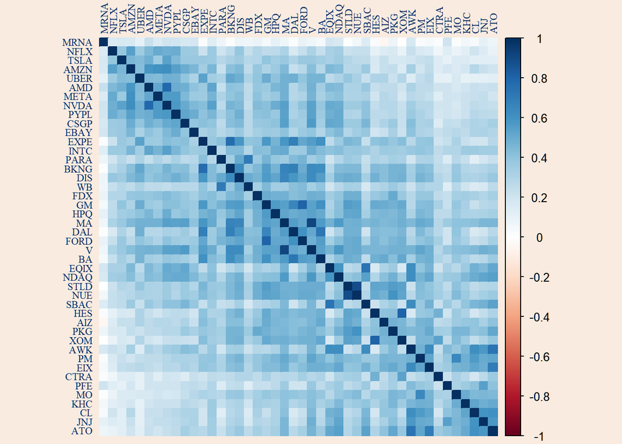

We need to test whether the correlations we are seeing are scientifically significant and not simply the result of chance. We can do this with hypothesis tests:

$$\begin{equation*}
\left\{\begin{matrix}
\ H_{0}: \left| \rho \right| \gt \tau\\
\ H_{1}: \left| \rho \right| \le \tau \\
\end{matrix}\right.
\end{equation*}$$

While the one above is the *classical* hypothesis testing scenario for a certain correlation value $\rho$ in our case the correlations are empirical, based on the stock data we got. To address the uncertainty for the real value of $\rho$ the definition of the test is translated to work for confidence intervals of coverage $1 - \alpha$ for the estimates of the correlation value between stocks, where $\alpha$ is the probability of the first type error (false discovery), the one we usually are more interested to avoid.  
Calling $C_n^\rho(\alpha)$ the confidence interval for the Pearson correlation the hypothesis tests become:

$$\begin{equation*}
\left\{\begin{matrix}
\ H_{0}: C_n^\rho(\alpha) \cap [-\tau, \tau] = \emptyset\\
\ H_{1}: C_n^\rho(\alpha) \cap [-\tau, \tau] \neq \emptyset \\
\end{matrix}\right.
\end{equation*}$$

We also need to address the problem of multiplicity. In order to construct a correlation graph, we must do a hypothesis test for each pair of variables. Each of the hypothesis tests ensures some $1 - \alpha$ coverage for each edge of the graph but the entire topology of the graph in this way does not have a $1 - \alpha$ probability of being true. It is therefore necessary to make a correction to the $\alpha$ value of the individual hypothesis test in order to be certain that the type-1 error rate of the overall topology of the graph is the desired one.

The simplest of this kind of the corrections is the *Bonferroni correction*, for which to ensure an overall type-1 error rate $\alpha$ over $n$ evaluations we have to use as alpha for each individual test $\alpha_i = \frac \alpha n$.

```r
# CI for the correlation coefficient -------

tanh.r <- atanh(r) # Perform Fisher Z-transform
sigma <- 1 / sqrt ( n-3 ) # Asymptotic variance

alpha <- 0.4

ncomb <- (n*(n-1))/2 # == factorial(n)/(factorial(n-2)*2) # Number of combinations of n elements taken 2 at a time

alpha.adj <- alpha / ncomb # Use Bonferroni correction
z.adj <- qnorm(1 - alpha.adj / 2)

# Confidence intervals without the autocorrelations !
upper.tanh.r = tanh.r[upper.tri(tanh.r)]
CI2 <- cbind('Lower Bound' = tanh(c(upper.tanh.r - sigma * z.adj)),
             'Upper Bound' = tanh(c(upper.tanh.r + sigma * z.adj)) )

# Set the names to the rows of CI to know which couples of stocks we're
# constructing the CI for
indeces <- which(upper.tri(tanh.r), arr.ind = TRUE)
indeces <- data.frame(indeces)

rownames(CI2) <- rep(NA, dim(indeces)[1])
for(i in 1:dim(indeces)[1]){
  rownames(CI2)[i] <- paste0(stocks_names[c(indeces[i,]$row)], ' ',
                             stocks_names[c(indeces[i,]$col)])
}
```

The confidence intervals for the correlations we obtained are very wide, we are therefore forced to consider higher values for $\alpha$, such as 0.4. This value alone seems high, however since it is the $\alpha$ value of the whole experiment the real $\alpha$ for each correlation between two stocks is:

$\frac{ 0.4 }{44! / (42!* 2!)} = 4.23e^{-4} \text{ since there are } \binom{44}{2} \text{ couples of variables.}$

### Choice of the threshold $\tau$

Once we have chosen the error of the first kind for the entire topology of the graph we can reason about the choice of $\tau$.  
We can use a data driven approach or focus on the topology of the graph to choose the threshold $\tau$.

#### Data Driven Approach

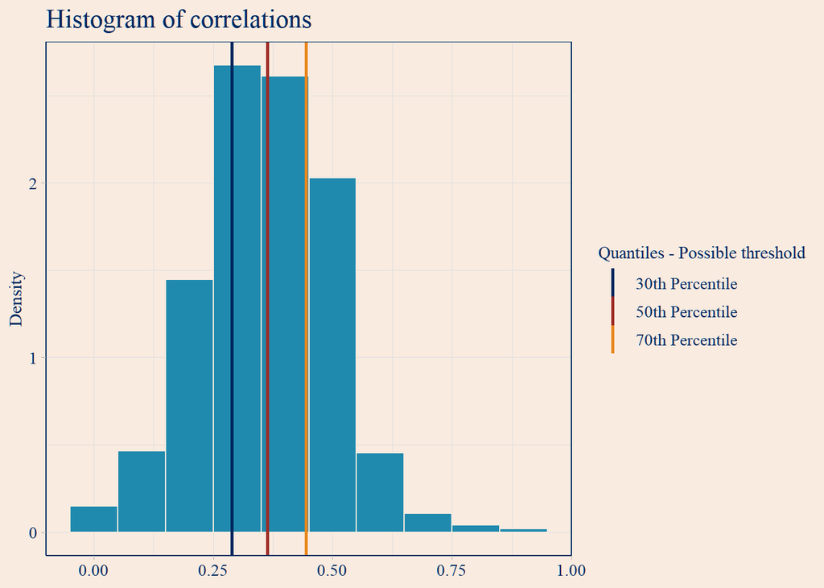

```r
tau1 <- quantile(r, 0.3)
tau2 <- quantile(r, 0.5)
tau3 <- quantile(r, 0.7)

check.threshold <- function(v, tau){
  return( (v["Lower Bound"] >  tau) |
            (v["Upper Bound"] < - tau) )
}

which.bigger.tau1 <- apply(CI2, MARGIN = 1, FUN = check.threshold, tau = tau1)
which.bigger.tau2 <- apply(CI2, MARGIN = 1, FUN = check.threshold, tau = tau2)
which.bigger.tau3 <- apply(CI2, MARGIN = 1, FUN = check.threshold, tau = tau3)
sum(which.bigger.tau1)
sum(which.bigger.tau2)
sum(which.bigger.tau3)
```

Looking at the correlation histogram, we can choose $\tau$ based on the quantiles. We decided to take the thirtieth, fiftieth and seventieth percentiles that correspond to $\tau$ values of respectively 0.289, 0.364 and 0.444.  
We then saw how many confidence intervals fall outside the range given by $[-\tau ,\tau]$ and with $\tau$ equal to 0.289 there are 11 confidence intervals left, with $\tau$ equal to 0.364 there are 8 and only 5 intervals with the last $\tau$ considered.

#### Graph Topology Approach

The second proposed approach is based on judging the graph topology ourselves and eyeballing a good trade-off between edges quantity and significance of the results. This approach is less rigorous but permit us to find better compromises.

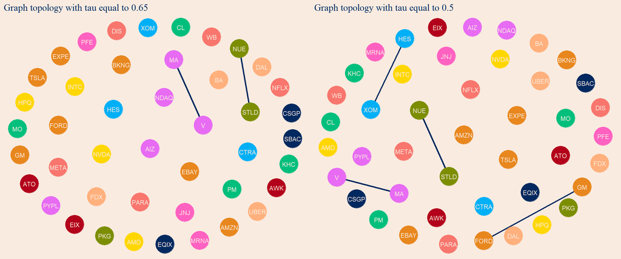

Using a high $\tau$ we end up with only few but meaningful connections. With $\tau = 0.5$ the only edges present are between Mastercard and Visa (payment services), Steel Dynamics and Nucor (steel manufacturing), Ford and General Motors (automotive manufacturing) and between Exxon Mobil Corp and Hess Corp (oil).

All those edges are somewhat to be expected given the similarity between the companies and probably the most interesting part of this result is the lack of certain edges between stocks that we would have expected to be related, but to delve deeper into this aspect we first want to explore how edges evolve lowering $\tau$.

It’s also interesting to note that the first two mentioned edges are particularly strong, they continue to exist even if we increase our demands by setting $\tau = 0.65$ (the first one continues to exist even for $\tau = 0.75$!). This is a symptom of both a very high correlation a high certainty of its value, represented by small confidence interval.

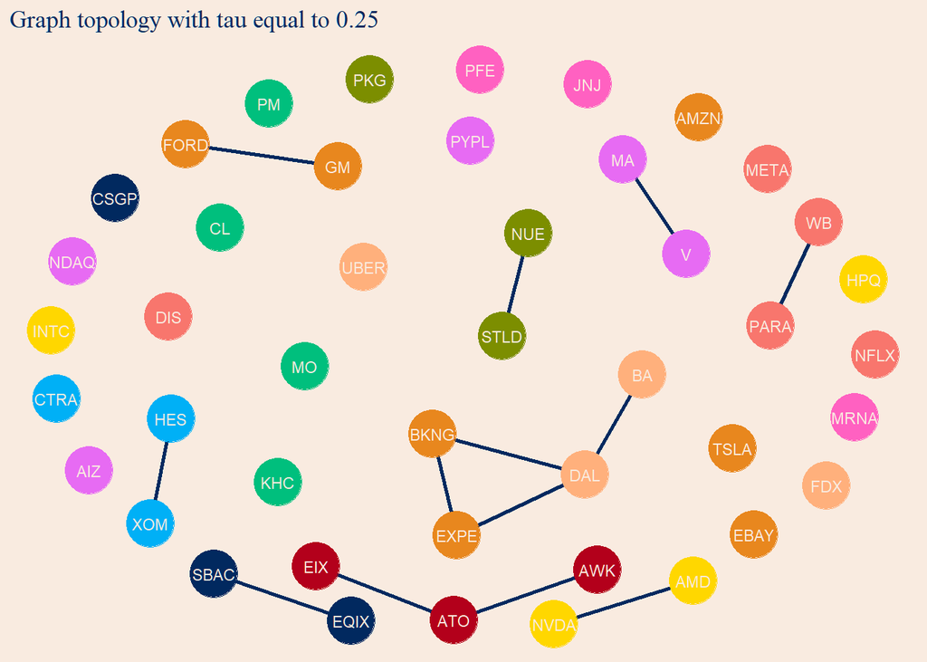

Lowering $\tau$ to $0.25$ we find new links between similar companies but also more complex relationships between other stocks. For example we now find edges from the tourism related stocks we mentioned above (Expedia, Booking, Delta Airlines and Boeing) and also between the three utilities companies.

The new “simple” links we found are between Warner Bros and Paramount (Entertainment), Nvidia and Advanced Micro Devices (Semiconductors) and SBA Communications and Equinix (Internet and telecommunications).

However even with such low taus values we miss to find many links we could have thought as obvious, as those between tobacco companies, entertainment, or even online retail.

Another interesting result is that the whole correlation finding setup seems to have *only found positive correlations*. While in this exercise we had the generic goal to find correlation between stocks, in real scenarios, following the *Modern Portfolio Theory*, we’d want to find negative correlations as to diversify our investing in order to reduce the risk of the whole investment.

To get more meaningful results in this regard we should expand the range of explored stocks arbitrarily or following some intel about this kind of behaviour, however we decided to not delve into this aspect as to not increase too much the number of considered stocks since it also increases the size of the confidence intervals by lowering the $\alpha_i$ but also to not inadvertently fall into *data snooping* by studying stocks and not include them in the final results.

## Shapley Values

Now that we set the parameters $\alpha$ and $\tau$ and we obtained the correlation graph for these chosen parameters, we need to compute some *bootstrapped* confidence intervals for the Shapley Values of the $p = 44$ stocks we chose for our portfolio. For this particoular scenario, the one of a *variance game*, we can calculate the Shapley value for the *j*-th stock (seen here as the player *j* of the game) as

$$\psi(j)^G=\mathbb{E}\left(X_j\right)-\omega \cdot
\operatorname{Cov}\left(X_j,
R_{\mathcal{P}}\right)=\mathbb{E}\left(X_j\right)-\omega \cdot
\sum_{r=1}^p \mathbb{C o v}\left(X_j, X_r\right)$$

We can observe that the definition depends on the parameter $\omega$, which measures how much the volatility of the stock affects the Shapley value itself. This becomes clearer if we observe that for this “game” the characteristic function is given by $\nu(\mathsf{C}) = U_\omega(R_\mathsf{C})$ and the utility function of a player for us is $U_\omega(X)=\mathbb{E}(X)-\omega \cdot \operatorname{Var}(X)$, where $\operatorname{Var(X)}$ expresses indeed the volatility of the stock. This makes the choice of the parameter extremely personal and based on the individual propensity for risk, so we choose to investigate the Shapley values behaviour for two different values of $\omega$; further analysis is made below.

Talking about the bootstrapped confidence intervals, we opted for the pivotal ones, computed at a level $1-\alpha = 0.95$ (so setting $\alpha$ at $0.05$). The CIs are based on the plug-in estimator of the Shapley calculated starting from their definition on the whole dataset/portfolio. To do so, we implemented one function that evaluates the estimate of the Shapley values on the whole dataset, and another one that allows us to select the “indeces” (the dates, in this case), in order to perform the bootstrap simulation to get the quantiles of the Shapley values distribution needed for the pivotal confidence intervals. Besides, we wrote two more functions that perform, respectively, the bootstrap simulation and the computation of the confidence intervals.

```r
covdf <- data.frame(cov(stocks_values))

# Function to compute the shapley values on the whole dataset
shap <- function(name, w=weigth, x = stocks_values, cov.df = covdf ){
  av <- mean(x[, name])
  tot.cov <- sum(cov.df[name])
  shap.value <- av - w*tot.cov
  return(shap.value)
}

# Function to bootstrap the shapley
shap4boot <- function(idx.vec, w=weigth){
  smpl.vec <- stocks_values[idx.vec, ]
  smpl.covdf <- data.frame(cov(stocks_values[idx.vec, ]))
  av <- apply(smpl.vec, MARGIN = 2, mean)
  tot.cov <- apply(smpl.covdf, MARGIN = 2, sum)
  shap.value <- av - w*tot.cov

  return(shap.value)
}

# Bootstrap function to get the quantiles
boot.sim <- function(w, alpha=0.05, B=10000, n = dim(stocks_values)[2],  m = dim(stocks_values)[1]){

  shap.mx <- matrix(NA, nrow=B, ncol= n)
  for(rep in 1:B){
    smpl.idx <- sample(c(1:m), m, replace = T )
    shap.mx[rep, ] <- shap4boot(smpl.idx, w)
  }
  shap.q1 <- apply(shap.mx, MARGIN = 2, FUN = quantile, probs = (1 - alpha/2))
  shap.q2 <-  apply(shap.mx, MARGIN = 2, FUN = quantile, probs = alpha/2)
  quantiles <- cbind( shap.q1, shap.q2 )
  rownames(quantiles) <- stocks_names
  return(quantiles)
}

# Function to get the pivotal CIs
piv.CI <- function(par.est, boot.quant){
  CI <-c(2*par.est - boot.quant)
  names(CI) <- c('lower', 'upper')
  return(CI)
}
```

To investigate how the Shapley values vary when changing $\omega$, as mentioned above, we chose to compute the CIs for these quantities both with a “small” ($\omega = 0.1$) and a “large” ($\omega = 10$) weight. Given that none of us has reasonably strong previous knowledge in the economic field and the only constraint we have on this parameter is that it has to be strictly positive, we don’t know if our setting is realistic or not and we can’t therefore consider the analysis to be made in a totally reasonable or real scenario.

```r
set.seed(123)
# Low weight  -----------------------------------------------------------
weight.low = 0.1

# Matrix of bootstrapped quantiles of the Shapley values' distribution
quant.boot.Shapley.low <- boot.sim(weight.low)
# Vector of the plug-in estimate of the Shapley values (on the whole dataset)
shap.vec.low <- apply(data.frame(stocks_names), MARGIN =1, FUN = shap, w = weight.low)
names(shap.vec.low) <- stocks_names

# CIs' construction
CI.shap.low <- c()
for(i in 1:n){ # n is the number of stocks
  CI <- piv.CI(shap.vec.low[i], quant.boot.Shapley.low[i,])
  CI.shap.low <- rbind(CI.shap.low, CI)
}

rownames(CI.shap.low) <- stocks_names

# High weight  -------------------------------------------------------------

weight.high = 10

# Matrix of bootstrapped quantiles of the Shapley values' distribution
quant.boot.Shapley.high <- boot.sim(weight.high)

# Vector of the plug-in estimate of the Shapley values (on the whole dataset)
shap.vec.high <- apply(data.frame(stocks_names), MARGIN =1, FUN = shap, w = weight.high)
names(shap.vec.high) <- stocks_names

# CIs' construction
CI.shap.high <- c()
for(i in 1:n){ # n is the number of stocks
  CI <- piv.CI(shap.vec.high[i], quant.boot.Shapley.high[i,])
  CI.shap.high <- rbind(CI.shap.high, CI)
}

rownames(CI.shap.high) <- stocks_names
```

To interpret the estimates we got, let us first recall that, as in any other type of game, the Shapley value of a player reflects its marginal contribution to the value of the grand coalition, that in this case is the total utility of the portfolio. A question that naturally arises from this intuitive interpretation is how to correctly interpret *negative* Shapley values. Getting back to the exercise’s setting, a possible answer to our question is given in [“Variance Allocation and Shapley Value”](https://arxiv.org/pdf/1606.09424.pdf): “*if a random variable contributes to hedge a risk, then it is “rewarded” with a negative Shapley value*”.

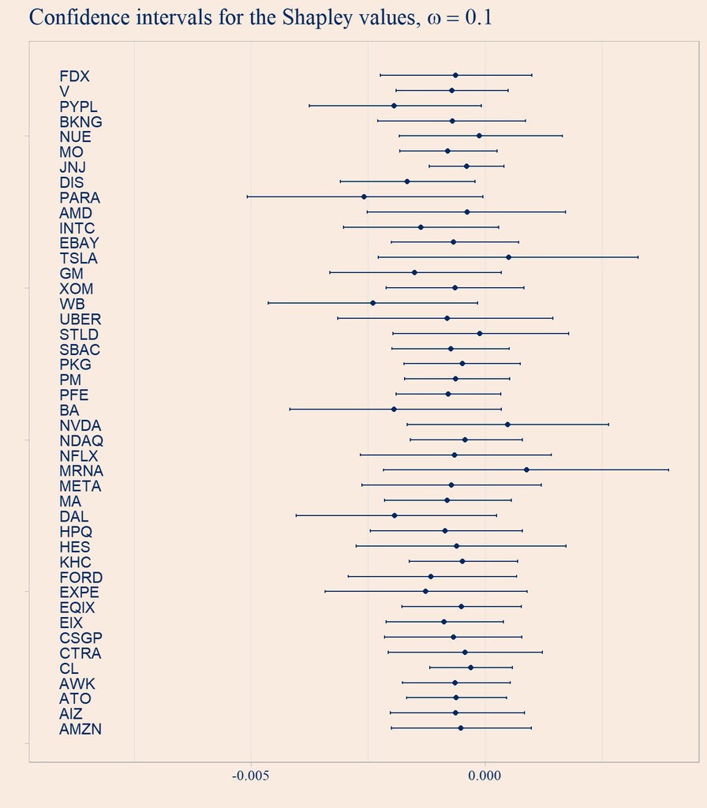

For the “low weight” ($\omega = 0.1$), we can see that almost all the confidence intervals for the Shapley values contain $0$, suggesting that most of the selected stocks may not have a relevant contribution to the total utility (recall that the Shapley values satisfy the “dummy player” property, so one possible cause of having a null Shapley value is indeed the one of being a “dummy player”, even though this is not necessary). However, the confidence intervals of the other stocks (PYPL, PARA, DIS, WB) have both the bounds below $0$, but not very significantly. These results makes us think that, in this scenario, none of the stocks we selected is dominant in terms of contribution to the total utility, but that the role they play in the “game” is more or less equivalent.

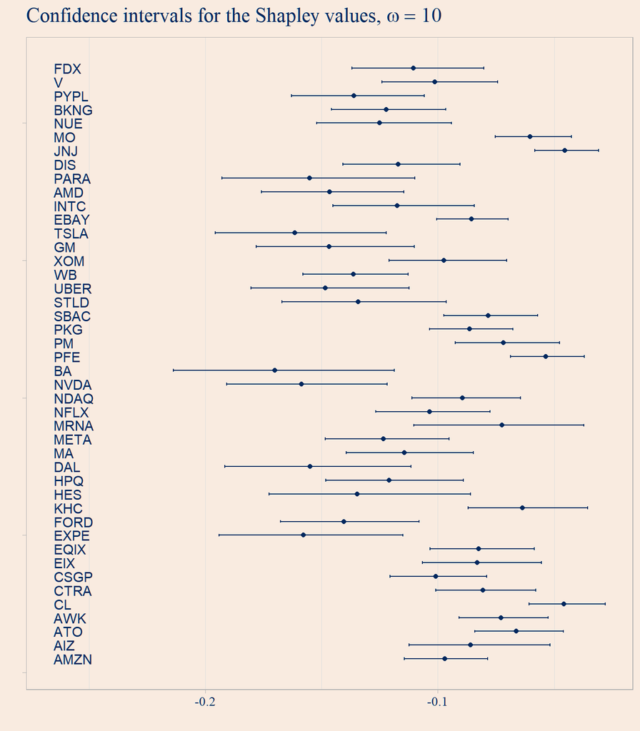

For the second choice of $\omega$, that is $\omega = 10$, we have that all the confidence intervals have both the bounds below $0$, meaning that all the Shapley values for this parameter setting are expected to be negative (at a $0.95$ level). This doesn’t necessarily mean that all the stocks contribute to hedge a risk, since the implication we reported above is the opposite one ($\text{stock contribute to hedge a risk} \implies \text{negative Shapley value}$, but viceversa is not necessarily true), still it could be an explanation for this observed behaviour, and not necassarily for all the stocks. However, increasing $\omega$ led to having more diverse estimates for the Shapley values (and the relative CIs), leading us to think that this time each stock stocks may have a different role in terms of contribution to the total utility, and that this quantity isn’t distributed as much equally between the players as before.